# Supervised Learning - Foundations Project: ReCell

```
Distribution of screen_size:
Distribution of main_camera_mp:
Distribution of selfie_camera_mp:
Distribution of int_memory:
Distribution of ram:
Distribution of battery:
Distribution of weight:
Distribution of days_used:
Distribution of normalized_new_price:
Distribution of age_of_model:
```

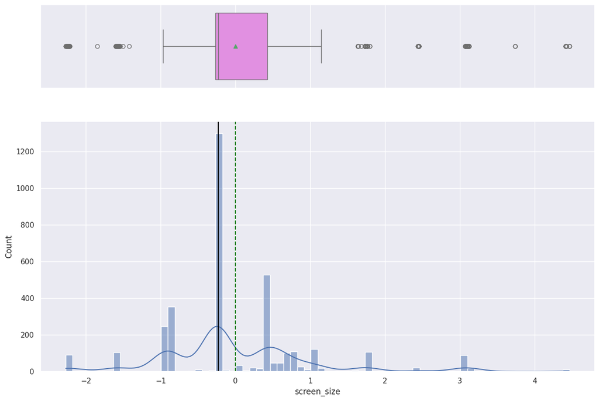

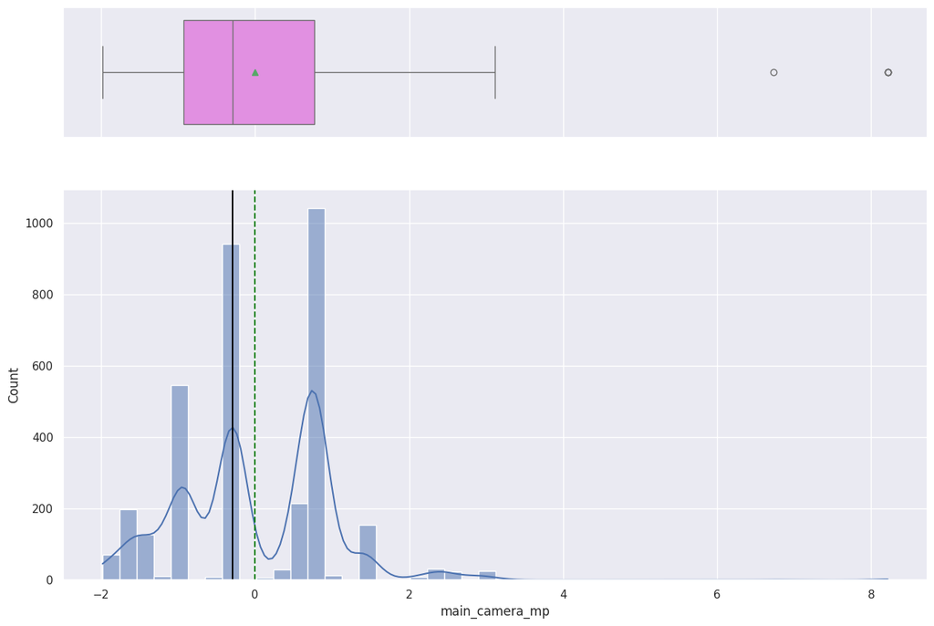

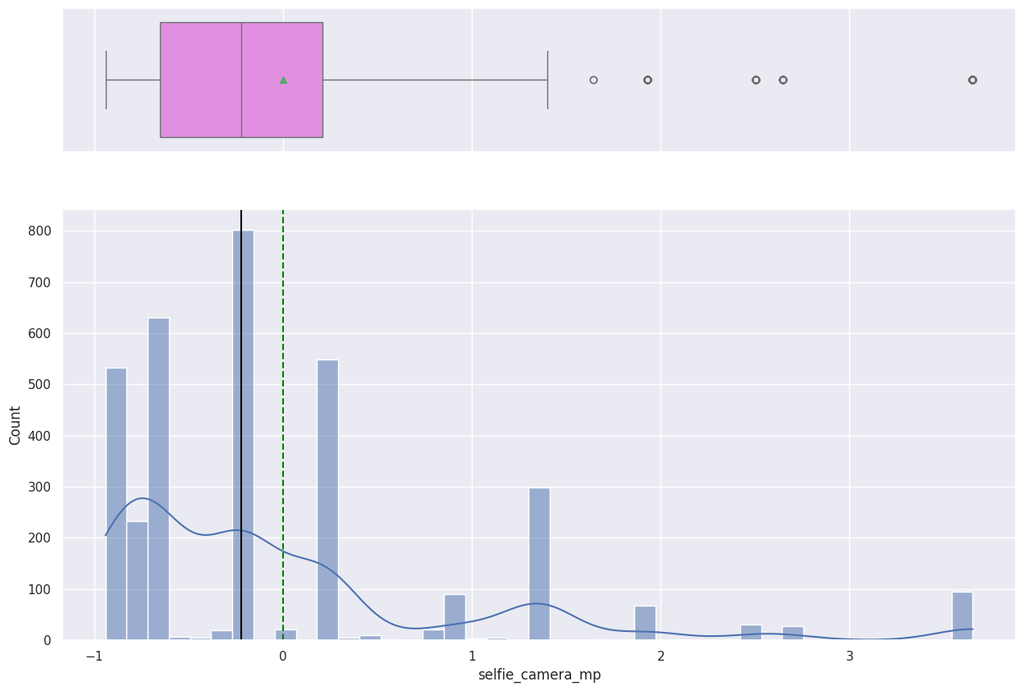

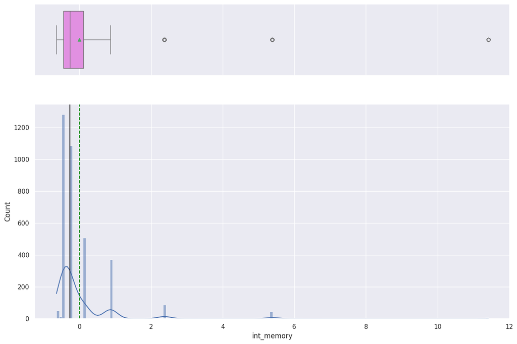

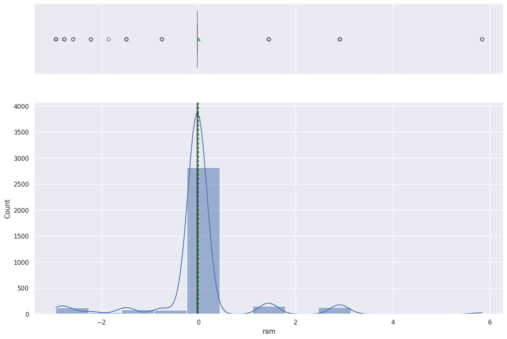

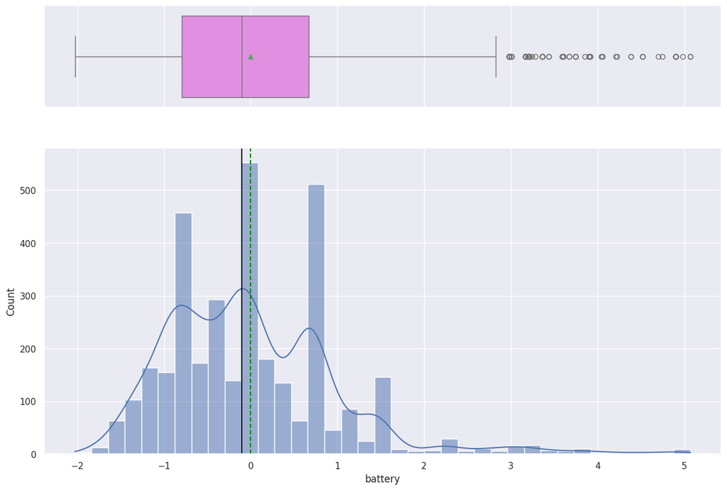

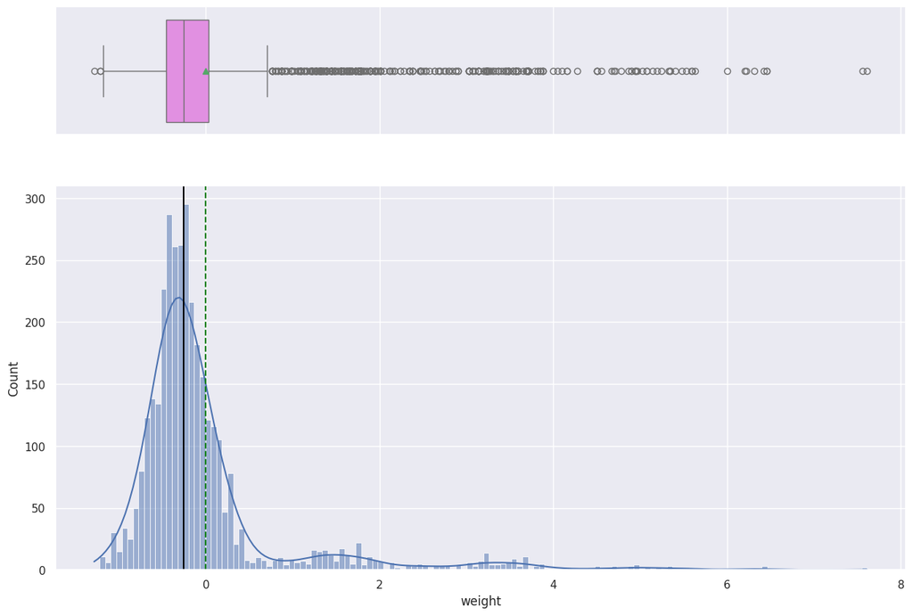

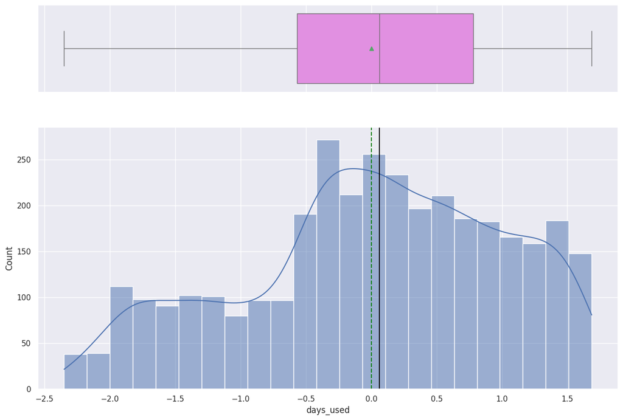

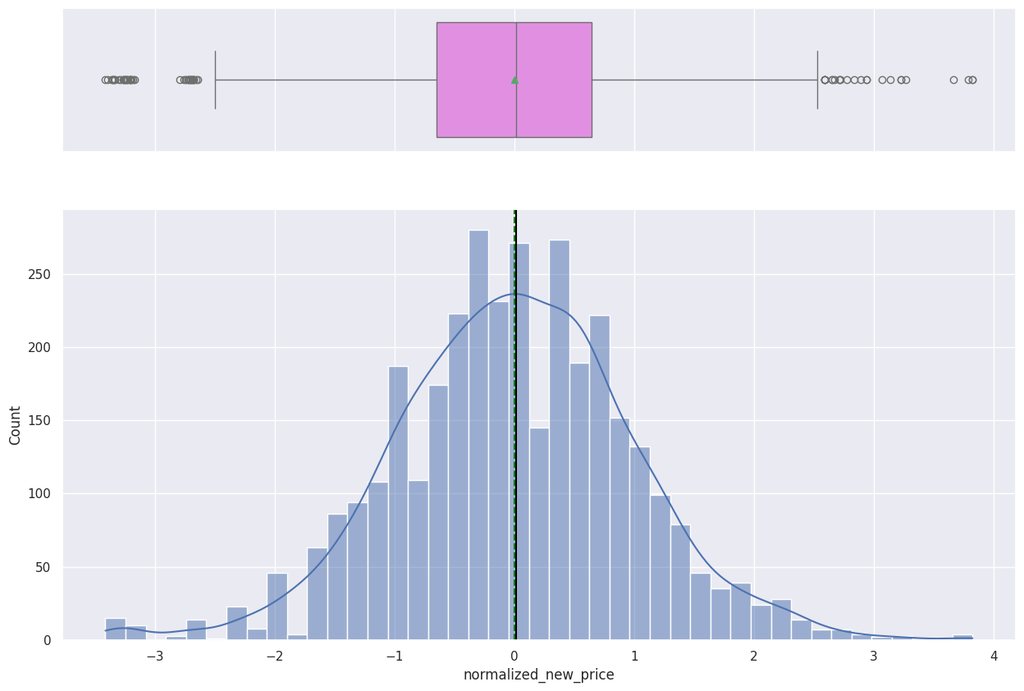

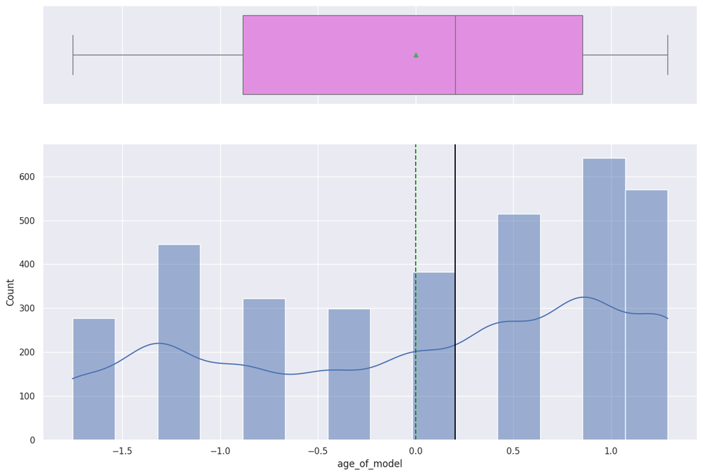

```python
for col in ['screen_size', 'main_camera_mp', 'selfie_camera_mp', 'int_memory', 'ram', 'battery', 'weight', 'days_used', 'normalized_new_price', 'age_of_model']:
    print(f"Distribution of {col}:")
    histogram_boxplot(df_encoded, col, kde=True)
```

To complete the visualization inspection of numerical feature distributions, I will generate the histogram and boxplot for the target variable normalized_used_price from the df_encoded DataFrame.

```python
print("Distribution of normalized_used_price:")
histogram_boxplot(df_encoded, 'normalized_used_price', kde=True)
```

[output not shown]

```
Distribution of normalized_used_price:
```

## Re-evaluate Correlations

Re-calculating and visualizing the correlation matrix (heatmap) of all numerical features (including the scaled ones and age_of_model) with normalized_used_price in the df_encoded DataFrame. It will confirm strong relationships and observe any changes post-scaling.

Visualizing the correlations of all numerical features (including scaled and engineered ones) with the target variable, I will calculate the correlation matrix and display it as a heatmap, focusing on 'normalized_used_price'.

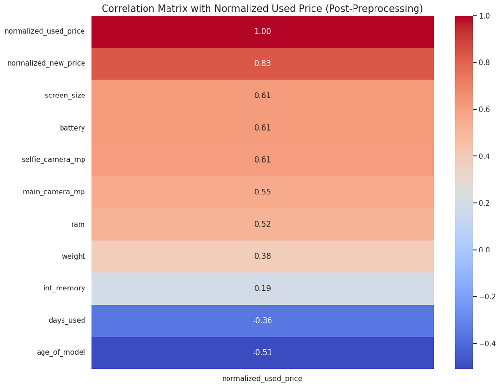

```python
plt.figure(figsize=(12, 10))
sns.heatmap(df_encoded.select_dtypes(include=np.number).corr()[['normalized_used_price']].sort_values(by='normalized_used_price', ascending=False), annot=True, cmap='coolwarm', fmt=".2f");
plt.title('Correlation Matrix with Normalized Used Price (Post-Preprocessing)', fontsize=15)
plt.show()
```

Observations from the post-preprocessing EDA, noting how the transformations have affected the data's distributions and structure, to confirm readiness for model building.

### Data Analysis

- The `df_encoded` DataFrame, containing 3454 entries and 49 columns, is free of missing values, with all columns showing 3454 non-null entries.
- Numerical features (e.g., `screen_size`, `main_camera_mp`, `ram`, `battery`, `weight`, `days_used`, `age_of_model`, `normalized_new_price`) have been successfully standardized, resulting in means very close to 0 and standard deviations very close to 1.
- Categorical features have been effectively one-hot encoded into 38 boolean columns, confirming the transformation.
- The target variable, `normalized_used_price`, has a mean of approximately 4.36 and a standard deviation of approximately 0.58.
- Visualizations of numerical feature distributions (histograms and boxplots) were generated for all specified columns, including `normalized_used_price` and the engineered `age_of_model`, allowing for a visual assessment of their shapes post-scaling.
- The correlation matrix with `normalized_used_price` for all numerical features, including scaled and engineered ones, was re-calculated and visualized as a heatmap, confirming relationships after preprocessing.
- The data is confirmed to be clean, scaled, and encoded appropriately, showing it is now ready for model building.
- Further analysis could involve selecting specific features based on their correlation with `normalized_used_price` for initial model training or feature engineering, especially for those revealing strong relationships.

## Model Building - Linear Regression

```python
# Separating the independent variables (X) and the dependent variable (y)
X = df_encoded.drop('normalized_used_price', axis=1)
y = df_encoded['normalized_used_price']

# Convert boolean columns to integer (0 or 1) for statsmodels compatibility
for col in X.select_dtypes(include='bool').columns:
    X[col] = X[col].astype(int)

# Splitting the data into training and testing sets
X_train, X_test, y_train, y_test = train_test_split(X, y, test_size=0.3, random_state=42)

# Adding a constant to the independent variables for statsmodels.OLS
X_train_sm = sm.add_constant(X_train)

olsmodel1 = sm.OLS(y_train, X_train_sm).fit()
print(olsmodel1.summary())
```

```
                              OLS Regression Results
=================================================================================
Dep. Variable:     normalized_used_price   R-squared:                       0.849
Model:                               OLS   Adj. R-squared:                  0.845
Method:                    Least Squares   F-statistic:                     276.3
Date:                   Sun, 07 Dec 2025   Prob (F-statistic):               0.00
Time:                           21:08:47   Log-Likelihood:                 122.14
No. Observations:                   2417   AIC:                            -146.3
Df Residuals:                       2368   BIC:                             137.4
Df Model:                             48
Covariance Type:               nonrobust
=========================================================================================
                            coef    std err          t      P>|t|      [0.025      0.975]
-----------------------------------------------------------------------------------------
const                     4.3873      0.043    101.768      0.000       4.303       4.472
screen_size               0.1109      0.013      8.233      0.000       0.084       0.137
main_camera_mp            0.1049      0.007     14.614      0.000       0.091       0.119
selfie_camera_mp          0.0821      0.008     10.039      0.000       0.066       0.098
int_memory                0.0154      0.006      2.675      0.008       0.004       0.027
ram                       0.0429      0.007      5.998      0.000       0.029       0.057
battery                  -0.0190      0.010     -1.992      0.047      -0.038      -0.000
weight                    0.0693      0.012      5.874      0.000       0.046       0.092
days_used                 0.0065      0.008      0.850      0.395      -0.008       0.022
normalized_new_price      0.2813      0.008     33.526      0.000       0.265       0.298
age_of_model             -0.0614      0.010     -5.853      0.000      -0.082      -0.041
brand_name_Alcatel       -0.0808      0.050     -1.624      0.104      -0.178       0.017
brand_name_Apple         -0.0519      0.148     -0.351      0.725      -0.342       0.238
brand_name_Asus           0.0114      0.049      0.231      0.817      -0.085       0.108
brand_name_BlackBerry     0.0320      0.072      0.444      0.657      -0.109       0.173
brand_name_Celkon        -0.2334      0.068     -3.425      0.001      -0.367      -0.100
brand_name_Coolpad       -0.0181      0.071     -0.255      0.799      -0.157       0.121
brand_name_Gionee        -0.0130      0.059     -0.222      0.825      -0.128       0.102
brand_name_Google        -0.1206      0.083     -1.458      0.145      -0.283       0.042
brand_name_HTC           -0.0389      0.050     -0.777      0.437      -0.137       0.059
brand_name_Honor         -0.0560      0.051     -1.101      0.271      -0.156       0.044
brand_name_Huawei        -0.0659      0.046     -1.429      0.153      -0.156       0.025
brand_name_Infinix        0.1229      0.114      1.082      0.279      -0.100       0.346
brand_name_Karbonn       -0.0564      0.068     -0.825      0.409      -0.190       0.078
brand_name_LG            -0.0643      0.047     -1.374      0.170      -0.156       0.027
brand_name_Lava          -0.0220      0.063     -0.349      0.727      -0.146       0.102
```

[output cut: 17 more lines]

```
brand_name_ZTE           -0.0425      0.048     -0.880      0.379      -0.137       0.052
os_Others                -0.0629      0.033     -1.932      0.053      -0.127       0.001
os_Windows               -0.0303      0.043     -0.698      0.486      -0.115       0.055
os_iOS                   -0.0068      0.148     -0.046      0.963      -0.297       0.283
4g_yes                    0.0393      0.016      2.422      0.015       0.007       0.071
5g_yes                   -0.0601      0.032     -1.850      0.064      -0.124       0.004
==============================================================================
Omnibus:                      234.874   Durbin-Watson:                   1.990
Prob(Omnibus):                  0.000   Jarque-Bera (JB):              638.608
Skew:                          -0.533   Prob(JB):                    2.13e-139
Kurtosis:                       5.281   Cond. No.                         109.
==============================================================================

Notes:
[1] Standard Errors assume that the covariance matrix of the errors is correctly specified.
```

## Model Performance Check

**Let's check the performance of the model using different metrics.**

- I will be using metric functions defined in sklearn for RMSE, MAE, and $R^2$.
- I will define a function to calculate MAPE and adjusted $R^2$.
- I will create a function which will print out all the above metrics in one go.

```python
# function to compute adjusted R-squared
def adj_r2_score(predictors, targets, predictions):
    r2 = r2_score(targets, predictions)
    n = predictors.shape[0]
    k = predictors.shape[1]
    return 1 - ((1 - r2) * (n - 1) / (n - k - 1))


# function to compute MAPE
def mape_score(targets, predictions):
    return np.mean(np.abs(targets - predictions) / targets) * 100


# function to compute different metrics to check performance of a regression model
def model_performance_regression(model, predictors, target):
    """
    Function to compute different metrics to check regression model performance

    model: regressor
    predictors: independent variables
    target: dependent variable
    """

    # predicting using the independent variables
    pred = model.predict(predictors)

    r2 = r2_score(target, pred)  # to compute R-squared
    adjr2 = adj_r2_score(predictors, target, pred)  # to compute adjusted R-squared
    rmse = np.sqrt(mean_squared_error(target, pred))  # to compute RMSE
    mae = mean_absolute_error(target, pred)  # to compute MAE
    mape = mape_score(target, pred)  # to compute MAPE

    # creating a dataframe of metrics
    df_perf = pd.DataFrame(
        {
            "RMSE": rmse,
            "MAE": mae,
            "R-squared": r2,
            "Adj. R-squared": adjr2,
            "MAPE": mape,
        },
        index=[0],
    )

    return df_perf
```

```python
# checking model performance on train set (seen 70% data)
print("Training Performance\n")
# The olsmodel1 was trained with X_train_sm, so we need to pass X_train_sm for prediction as well.
olsmodel1_train_perf = model_performance_regression(olsmodel1, X_train_sm, y_train)
olsmodel1_train_perf
```

```
Training Performance
```

|  | RMSE | MAE | R-squared | Adj. R-squared | MAPE |
| --- | --- | --- | --- | --- | --- |
| 0 | 0.230046 | 0.178413 | 0.848511 | 0.845374 | 4.291322 |

```python
# checking model performance on test set (seen 30% data)
print("Test Performance\n")
# Add constant to X_test to match the training data (X_train_sm) used for olsmodel1
X_test_sm = sm.add_constant(X_test)
olsmodel1_test_perf = model_performance_regression(olsmodel1, X_test_sm, y_test)
olsmodel1_test_perf
```

```
Test Performance
```

|  | RMSE | MAE | R-squared | Adj. R-squared | MAPE |
| --- | --- | --- | --- | --- | --- |
| 0 | 0.238234 | 0.188312 | 0.833336 | 0.825062 | 4.50779 |

## Checking Linear Regression Assumptions

- In order to make statistical inferences from a linear regression model, it is important to ensure that the assumptions of linear regression are satisfied.

I will be checking the following Linear Regression assumptions:

1. **No Multicollinearity**
2. **Linearity of variables**
3. **Independence of error terms**
4. **Normality of error terms**
5. **No Heteroscedasticity**

## TEST FOR MULTICOLLINEARITY

I will test for multicollinearity using VIF.

**General Rule of thumb**:

- If VIF is 1 then there is no correlation between the $k$th predictor and the remaining predictor variables.
- If VIF exceeds 5 or is close to exceeding 5, we say there is moderate multicollinearity.
- If VIF is 10 or exceeding 10, it shows signs of high multicollinearity

Let's define a function to check VIF.

```python
#Let's define a function to check VIF.

def checking_vif(predictors):
    vif = pd.DataFrame()
    vif["feature"] = predictors.columns

    # calculating VIF for each feature
    vif["VIF"] = [
        variance_inflation_factor(predictors.values, i)
        for i in range(len(predictors.columns))
    ]
    return vif
```

```python
vif_results = checking_vif(X_train_sm)
print(vif_results.sort_values(by='VIF', ascending=False).head(10))
```

```
               feature        VIF
0                const  83.163241
12    brand_name_Apple  11.192704
34   brand_name_Others  10.834358
46              os_iOS  10.036219
1          screen_size   8.264079
37  brand_name_Samsung   8.012882
7               weight   6.405860
21   brand_name_Huawei   6.397788
24       brand_name_LG   5.353108
10        age_of_model   4.860595
```

## Removing Multicollinearity (if needed)

To remove multicollinearity

Let's define a function that will help us do this.

```python
def treating_multicollinearity(predictors, target, high_vif_columns):
    """
    Checking the effect of dropping the columns showing high multicollinearity
    on model performance (adj. R-squared and RMSE)

    predictors: independent variables
    target: dependent variable
    high_vif_columns: columns having high VIF
    """
    # empty lists to store adj. R-squared and RMSE values
    adj_r2 = []
    rmse = []

    # build ols models by dropping one of the high VIF columns at a time
    # store the adjusted R-squared and RMSE in the lists defined previously
    for cols in high_vif_columns:
        # defining the new train set
        train = predictors.loc[:, ~predictors.columns.str.startswith(cols)]

        # create the model
        olsmodel = sm.OLS(target, train).fit()

        # adding adj. R-squared and RMSE to the lists
        adj_r2.append(olsmodel.rsquared_adj)
        rmse.append(np.sqrt(olsmodel.mse_resid))

    # creating a dataframe for the results
    temp = pd.DataFrame(
        {
            "col": high_vif_columns,
            "Adj. R-squared after_dropping col": adj_r2,
            "RMSE after dropping col": rmse,
        }
    ).sort_values(by="Adj. R-squared after_dropping col", ascending=False)
    temp.reset_index(drop=True, inplace=True)

    return temp
```

```python
x_train2 = X_train_sm.copy() # Initialize x_train2 with the full set of predictors
col_list = ['screen_size', 'weight']

res = treating_multicollinearity(x_train2, y_train, col_list)
res
```

|  | col | Adj. R-squared after_dropping col | RMSE after dropping col |
| --- | --- | --- | --- |
| 0 | weight | 0.843254 | 0.234052 |
| 1 | screen_size | 0.841083 | 0.235667 |

```python
col_to_drop = 'weight'
x_train2 = x_train2.loc[:, ~x_train2.columns.str.startswith(col_to_drop)]
X_test_sm_temp = sm.add_constant(X_test)
x_test2 = X_test_sm_temp.loc[:, ~X_test_sm_temp.columns.str.startswith(col_to_drop)]

# Check VIF now
vif = checking_vif(x_train2)
print("VIF after dropping ", col_to_drop)
vif
```

```
VIF after dropping  weight
```

|  | feature | VIF |
| --- | --- | --- |
| 0 | const | 83.014978 |
| 1 | screen_size | 3.671687 |
| 2 | main_camera_mp | 2.192173 |
| 3 | selfie_camera_mp | 2.833513 |
| 4 | int_memory | 1.361787 |
| 5 | ram | 2.247033 |
| 6 | battery | 3.758181 |
| 7 | days_used | 2.573566 |
| 8 | normalized_new_price | 3.219952 |
| 9 | age_of_model | 4.730750 |
| 10 | brand_name_Alcatel | 3.447958 |
| 11 | brand_name_Apple | 11.171734 |
| 12 | brand_name_Asus | 3.649997 |
| 13 | brand_name_BlackBerry | 1.622620 |
| 14 | brand_name_Celkon | 1.873182 |
| 15 | brand_name_Coolpad | 1.574076 |
| 16 | brand_name_Gionee | 2.075543 |
| 17 | brand_name_Google | 1.388534 |
| 18 | brand_name_HTC | 3.458719 |
| 19 | brand_name_Honor | 3.554010 |
| 20 | brand_name_Huawei | 6.389385 |
| 21 | brand_name_Infinix | 1.190122 |
| 22 | brand_name_Karbonn | 1.625673 |
| 23 | brand_name_LG | 5.348068 |
| 24 | brand_name_Lava | 1.821992 |
| 25 | brand_name_Lenovo | 4.704592 |
| 26 | brand_name_Meizu | 2.407228 |
| 27 | brand_name_Micromax | 3.774829 |
| 28 | brand_name_Microsoft | 2.092782 |
| 29 | brand_name_Motorola | 3.477035 |
| 30 | brand_name_Nokia | 3.745438 |
| 31 | brand_name_OnePlus | 1.583955 |
| 32 | brand_name_Oppo | 4.281812 |
| 33 | brand_name_Others | 10.834357 |
| 34 | brand_name_Panasonic | 1.888013 |
| 35 | brand_name_Realme | 1.960067 |
| 36 | brand_name_Samsung | 8.007177 |
| 37 | brand_name_Sony | 2.879010 |
| 38 | brand_name_Spice | 1.637635 |
| 39 | brand_name_Vivo | 3.718148 |
| 40 | brand_name_XOLO | 2.157255 |
| 41 | brand_name_Xiaomi | 4.069399 |
| 42 | brand_name_ZTE | 4.339107 |
| 43 | os_Others | 1.735265 |
| 44 | os_Windows | 1.740287 |
| 45 | os_iOS | 9.996787 |
| 46 | 4g_yes | 2.534922 |
| 47 | 5g_yes | 1.837499 |

### Dropping high p-value variables (if needed)

- I will be dropping the predictor variables having a p-value greater than 0.05 as they do not significantly impact the target variable.
- But sometimes p-values change after dropping a variable. So, I'll not drop all variables at once.
- Instead, I will do this following:
  - Build a model, check the p-values of the variables, and drop the column with the highest p-value.
  - Create a new model without the dropped feature, check the p-values of the variables, and drop the column with the highest p-value.
  - Repeat the above two steps till there are no columns with p-value > 0.05.

The above process can also be done manually by picking one variable at a time that has a high p-value, dropping it, and building a model again. But that might be a little tedious and using a loop will be more efficient.

```python
# initial list of columns
predictors = x_train2.copy()
cols = predictors.columns.tolist()

# setting an initial max p-value
max_p_value = 1

while len(cols) > 0:
    # defining the train set
    x_train_aux = predictors[cols]

    # fitting the model
    model = sm.OLS(y_train, x_train_aux).fit()

    # getting the p-values and the maximum p-value
    p_values = model.pvalues
    max_p_value = max(p_values)

    # name of the variable with maximum p-value
    feature_with_p_max = p_values.idxmax()

    if max_p_value > 0.05:
        cols.remove(feature_with_p_max)
    else:
        break

selected_features = cols
print(selected_features)
```

```
['const', 'screen_size', 'main_camera_mp', 'selfie_camera_mp', 'int_memory', 'ram', 'normalized_new_price', 'age_of_model', 'brand_name_Celkon', '4g_yes']
```

```python
x_train3 = x_train2[selected_features]
x_test3 = x_test2[selected_features]
```

```python
olsmodel2 = sm.OLS(y_train, x_train3).fit()
print(olsmodel2.summary())
```

```
                              OLS Regression Results
=================================================================================
Dep. Variable:     normalized_used_price   R-squared:                       0.843
Model:                               OLS   Adj. R-squared:                  0.842
Method:                    Least Squares   F-statistic:                     1434.
Date:                   Sun, 07 Dec 2025   Prob (F-statistic):               0.00
Time:                           20:43:15   Log-Likelihood:                 77.225
No. Observations:                   2417   AIC:                            -134.5
Df Residuals:                       2407   BIC:                            -76.55
Df Model:                              9
Covariance Type:               nonrobust
========================================================================================
                           coef    std err          t      P>|t|      [0.025      0.975]
----------------------------------------------------------------------------------------
const                    4.3384      0.011    380.386      0.000       4.316       4.361
screen_size              0.1670      0.006     29.222      0.000       0.156       0.178
main_camera_mp           0.1002      0.006     15.685      0.000       0.088       0.113
selfie_camera_mp         0.0793      0.008     10.251      0.000       0.064       0.094
int_memory               0.0137      0.006      2.423      0.015       0.003       0.025
ram                      0.0320      0.006      5.283      0.000       0.020       0.044
normalized_new_price     0.2795      0.008     36.915      0.000       0.265       0.294
age_of_model            -0.0423      0.008     -5.321      0.000      -0.058      -0.027
brand_name_Celkon       -0.1968      0.054     -3.665      0.000      -0.302      -0.092
4g_yes                   0.0393      0.015      2.579      0.010       0.009       0.069
==============================================================================
Omnibus:                      236.526   Durbin-Watson:                   1.993
Prob(Omnibus):                  0.000   Jarque-Bera (JB):              647.049
Skew:                          -0.535   Prob(JB):                    3.13e-141
Kurtosis:                       5.298   Cond. No.                         19.8
==============================================================================

Notes:
[1] Standard Errors assume that the covariance matrix of the errors is correctly specified.
```

```python
# checking model performance on test set (seen 30% data)
print("Test Performance\n")
olsmodel2_test_perf = model_performance_regression(olsmodel2, x_test3, y_test)
olsmodel2_test_perf
```

```
Test Performance
```

|  | RMSE | MAE | R-squared | Adj. R-squared | MAPE |
| --- | --- | --- | --- | --- | --- |
| 0 | 0.241178 | 0.190888 | 0.829191 | 0.827526 | 4.568832 |

## TEST FOR LINEARITY AND INDEPENDENCE

- I will test for linearity and independence by making a plot of fitted values vs residuals and checking for patterns.
- If there is no pattern, then I will say the model is linear and residuals are independent.
- Otherwise, the model is showing signs of non-linearity and residuals are not independent.

```python
# let us create a dataframe with actual, fitted and residual values
df_pred = pd.DataFrame()

df_pred["Actual Values"] = y_train  # actual values
df_pred["Fitted Values"] = olsmodel2.fittedvalues  # predicted values
df_pred["Residuals"] = olsmodel2.resid  # residuals

df_pred.head()
```

|  | Actual Values | Fitted Values | Residuals |
| --- | --- | --- | --- |
| 1744 | 4.261975 | 4.306455 | -0.044479 |
| 3141 | 4.175156 | 3.823123 | 0.352033 |
| 1233 | 4.117410 | 4.437012 | -0.319602 |
| 3046 | 3.782597 | 3.839788 | -0.057191 |
| 2649 | 3.981922 | 3.935875 | 0.046047 |

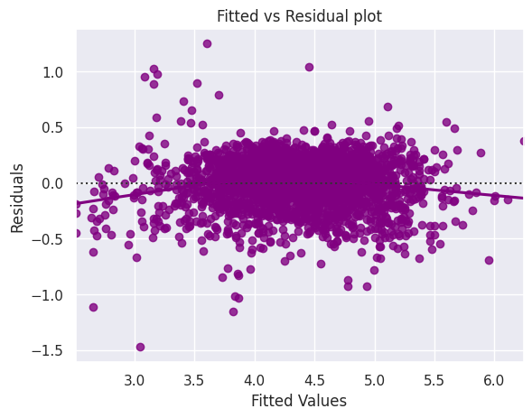

```python
# let's plot the fitted values vs residuals

sns.residplot(
    data=df_pred, x="Fitted Values", y="Residuals", color="purple", lowess=True
)
plt.xlabel("Fitted Values")
plt.ylabel("Residuals")
plt.title("Fitted vs Residual plot")
plt.show()
```

### TEST FOR NORMALITY

- I will test for normality by checking the distribution of residuals, by checking the Q-Q plot of residuals, and by using the Shapiro-Wilk test.
- If the residuals follow a normal distribution, they will make a straight line plot, otherwise not.
- If the p-value of the Shapiro-Wilk test is greater than 0.05, we can say the residuals are normally distributed.

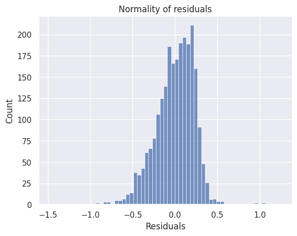

```python
sns.histplot(data=df_pred, x='Residuals');
plt.title("Normality of residuals")
plt.show()
```

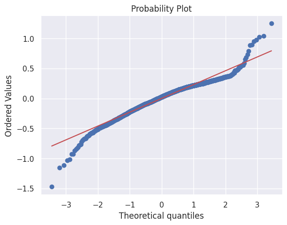

```python
import pylab
import scipy.stats as stats

stats.probplot(df_pred['Residuals'], dist="norm", plot=pylab)
plt.show()
```

```python
stats.shapiro(df_pred['Residuals'])
```

```
ShapiroResult(statistic=np.float64(0.9641212173261121), pvalue=np.float64(4.738535611322251e-24))
```

## TEST FOR HOMOSCEDASTICITY

- I will test for homoscedasticity using the goldfeldquandt test.
- If we get a p-value greater than 0.05, I will say that the residuals are homoscedastic. Otherwise, they are heteroscedastic.

```python
import statsmodels.stats.api as sms
from statsmodels.compat import lzip

name = ["F statistic", "p-value"]
test = sms.het_goldfeldquandt(df_pred["Residuals"], x_train3)
lzip(name, test)
```

```
[('F statistic', np.float64(0.9244081193962604)),
 ('p-value', np.float64(0.9130999803144949))]
```

## Final Model

```python
olsmodel_final = sm.OLS(y_train, x_train3).fit()
print(olsmodel_final.summary())
```

```
                              OLS Regression Results
=================================================================================
Dep. Variable:     normalized_used_price   R-squared:                       0.843
Model:                               OLS   Adj. R-squared:                  0.842
Method:                    Least Squares   F-statistic:                     1434.
Date:                   Sun, 07 Dec 2025   Prob (F-statistic):               0.00
Time:                           21:08:10   Log-Likelihood:                 77.225
No. Observations:                   2417   AIC:                            -134.5
Df Residuals:                       2407   BIC:                            -76.55
Df Model:                              9
Covariance Type:               nonrobust
========================================================================================
                           coef    std err          t      P>|t|      [0.025      0.975]
----------------------------------------------------------------------------------------
const                    4.3384      0.011    380.386      0.000       4.316       4.361
screen_size              0.1670      0.006     29.222      0.000       0.156       0.178
main_camera_mp           0.1002      0.006     15.685      0.000       0.088       0.113
selfie_camera_mp         0.0793      0.008     10.251      0.000       0.064       0.094
int_memory               0.0137      0.006      2.423      0.015       0.003       0.025
ram                      0.0320      0.006      5.283      0.000       0.020       0.044
normalized_new_price     0.2795      0.008     36.915      0.000       0.265       0.294
age_of_model            -0.0423      0.008     -5.321      0.000      -0.058      -0.027
brand_name_Celkon       -0.1968      0.054     -3.665      0.000      -0.302      -0.092
4g_yes                   0.0393      0.015      2.579      0.010       0.009       0.069
==============================================================================
Omnibus:                      236.526   Durbin-Watson:                   1.993
Prob(Omnibus):                  0.000   Jarque-Bera (JB):              647.049
Skew:                          -0.535   Prob(JB):                    3.13e-141
Kurtosis:                       5.298   Cond. No.                         19.8
==============================================================================

Notes:
[1] Standard Errors assume that the covariance matrix of the errors is correctly specified.
```

```python
# checking model performance on train set (seen 70% data)
print("Training Performance\n")
olsmodel_final_train_perf = model_performance_regression(olsmodel_final, x_train3, y_train)
olsmodel_final_train_perf
```

```
Training Performance
```

|  | RMSE | MAE | R-squared | Adj. R-squared | MAPE |
| --- | --- | --- | --- | --- | --- |
| 0 | 0.234362 | 0.181678 | 0.842774 | 0.84212 | 4.37654 |

```python
# checking model performance on test set (seen 30% data)
print("Test Performance\n")
olsmodel_final_test_perf = model_performance_regression(olsmodel_final, x_test3, y_test)
olsmodel_final_test_perf
```

```
Test Performance
```

|  | RMSE | MAE | R-squared | Adj. R-squared | MAPE |
| --- | --- | --- | --- | --- | --- |
| 0 | 0.241178 | 0.190888 | 0.829191 | 0.827526 | 4.568832 |

## Actionable Insights and Recommendations

## Actionable Insights

Based on an in-depth analysis and the Linear Regression model, these are some actionable insights for ReCell to develop a comprehensive pricing strategy for used and refurbished devices:

- With a substantial positive coefficient, by far, the normalized_new_price is the strongest predictor of normalized_used_price. Based on this intuition, expensive new devices, however, retain higher usage values.
- The age_of_model (derived from release_year) shows that older devices get lower prices, with a significant negative coefficient confirming it.
- The screen_size, selfie_camera_mp, main_camera_mp, ram, int_memory, and weight have significant positive coefficients. This shows that devices with better/higher specifications command higher used prices.
- It is counter-intuitive for a desirable feature based on the battery coefficient that was slightly negative.
- Whereas many brand_name dummy variables were not significant individually , brand_name_Celkon notably had a negative coefficient, and 4g_yes had a positive one. os_iOS and brand_name_Apple showed high multicollinearity, but Apple devices are generally premium.
- The days_used features were not a statistically significant predictor in this model.
- Dynamic trends can shift based on the nature of the used device market because the model is built on historical data up to 2021.
- The residuals were not perfectly normally distributed.

By implementing these data-driven insights, ReCell can develop a more accurate, robust, and dynamic pricing strategy that aligns with market realities and maximizes profitability in the used and refurbished device market.

## Actionable Recommendations

Based on an in-depth analysis and the Linear Regression model, these are some actionable recommendations for ReCell to develop a comprehensive pricing strategy for used and refurbished devices:

- The original new price of a device should be used as the baseline for its used pricing algorithm, as the baseline for its used pricing algorithm and the dynamic pricing model must weigh heavily on this factor.
- Implement depreciation curve that is based on the device's age. However, newer models will be priced higher, while older models face a consistent price reduction. Inventory management helps in prioritizing quicker sale of older stock.
- When evaluating purchase or sale for devices, ReCell should focus on these specifications in its pricing models. Devices with larger screens, more RAM, higher megapixel cameras, and greater internal storage should get premium priced. For marketing, these highlighted features can be justifiable prices to customers.
- Investigate further this relationship . It might show that older devices are associated with very large batteries, or larger tablets that might have a demand profile differently. If the negative correlation persists, ReCell should not price higher for larger batteries and instead consider the device type and age.
- Brands like Celkon, expectations for lower pricing should be set. As a significant factor, 4G-enabled devices are priced competitively. For marketing, these features can be highlighted to justify prices to customers. For premium brands like Apple, they generally command higher prices despite multicollinearity with iOS. For more nuanced pricing strategies, place more emphasis on market segmentation by brand and operating system.
- While it's a proxy for wear and tear, other factors like initial new price and age of model seem to capture the majority of price depreciation. ReCell can focus more on the age of the model and the device condition and less on the exact days_used which is better reflected in other aspects of a used device's value.
- Periodically, ReCell should retrain the model with the latest data and add new features (e.g., grade of refurbishment and condition) as they become available. Adoption of 5G(not currently significant, but growing) could become important in the future.
- For future iterations, explore the transformations of the normalized_used_price (e.g., logarithmic) or alternative regression models (e.g., tree-based models) which are less sensitive to this assumption, if higher prediction accuracy is required or if the current model struggles with specific price ranges.